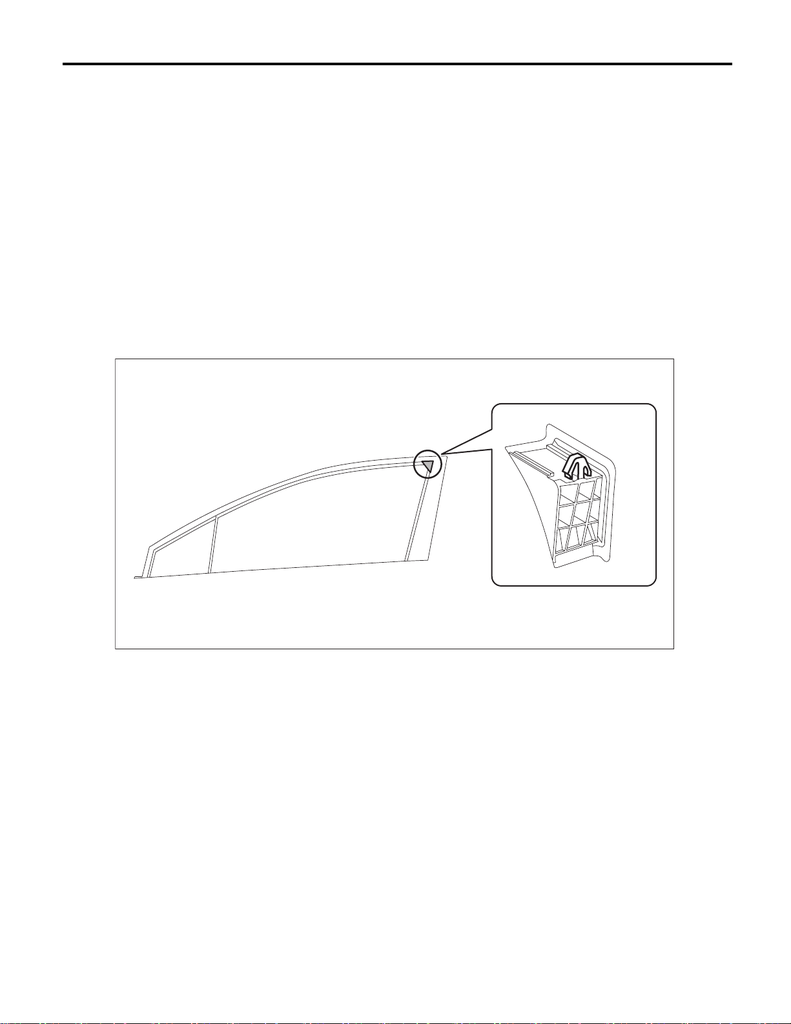

EB-24

Front Door

EXTERIOR BODY PANELS

4. Front Door

A: REMOVAL

1. FRONT DOOR PANEL

1) Disconnect the ground cable from battery and wait for at least 60 seconds before starting work. <Ref. to

NT-5, BATTERY, NOTE, Note.>

NOTE:

For models other than STI model, disconnect the ground terminal from battery sensor.

2) Remove the trim panel - front door. <Ref. to EI-56, FRONT DOOR, REMOVAL, Door Trim.>

3) Remove the sealing cover - front door. <Ref. to EB-32, REMOVAL, Front Sealing Cover.>

4) Remove the outer mirror assembly. <Ref. to GW-26, REMOVAL, Outer Mirror Assembly.>

5) Remove the front door speaker assembly. <Ref. to ET-10, DOOR SPEAKER, REMOVAL, Front Speak-

er.>

6) Remove the cover B pillar - front door INN.

CAUTION:

Always replace with a new part, because engagement of the claw weakens.

7) Remove the front door impact sensor assembly. <Ref. to AB-52, REMOVAL, Front Door Impact Sensor.>

8) Remove the glass assembly - front door and the glass - front door partition. <Ref. to GW-19, REMOVAL,

Front Door Glass.>

9) Remove the regulator & motor assembly - front of the front door. <Ref. to GW-23, REMOVAL, Front Reg-

ulator and Motor Assembly.>

10) Remove the latch and actuator assembly - front. <Ref. to SL-37, REMOVAL, Front Door Latch and Door

Lock Actuator Assembly.>

11) Remove the handle - door outer. <Ref. to SL-33, REMOVAL, Front Outer Handle.>

12) Remove the weather strip - front door. <Ref. to EB-58, REPLACEMENT, Weather Strip.>

EB-00783

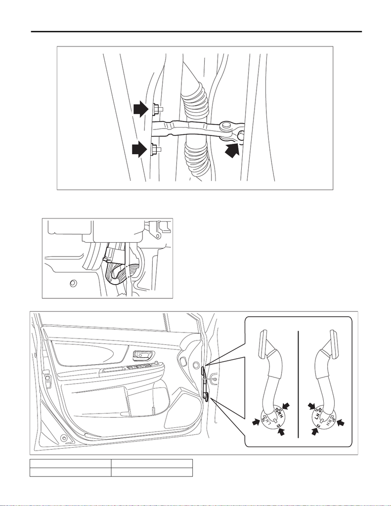

EB-25

Front Door

EXTERIOR BODY PANELS

13) Remove the bolts and nuts, and then detach the checker assembly - front door.

14) Remove the cover side sill - front INN and cover side sill - front. <Ref. to EI-81, REMOVAL, Lower Inner Trim.>

15) Disconnect the front door harness connectors.

(1) Disconnect the connector of door harness from body harness.

(2) Push in the claws to remove the grommet, and pull out the door harness connector.

EB-00889

EB-00151

A Driver’s side

B Passenger’s side

EB-00753

AB

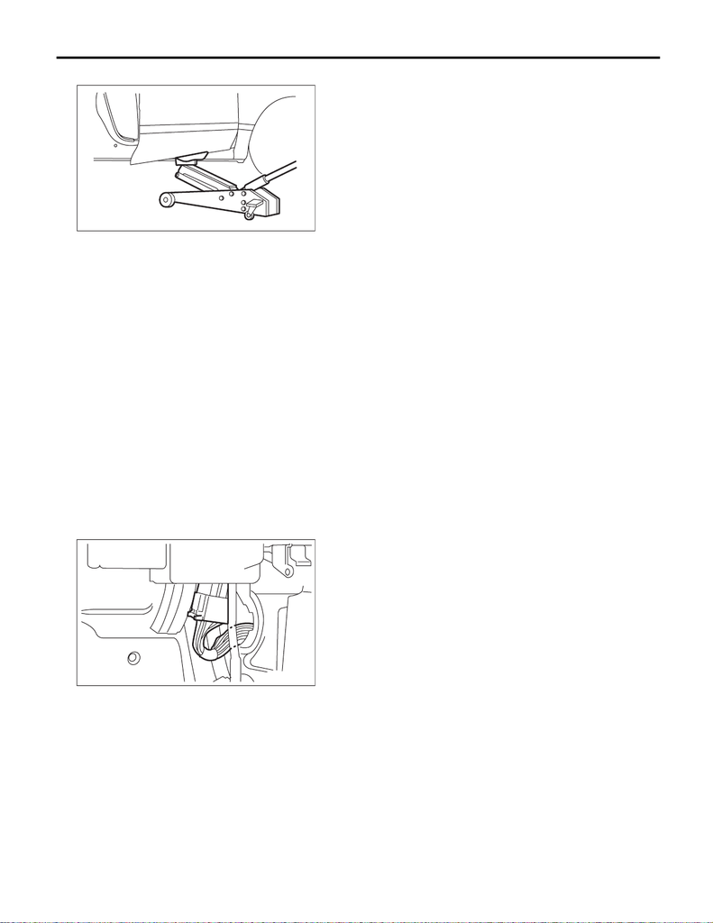

EB-26

Front Door

EXTERIOR BODY PANELS

16) Before removing the panel assembly - front door, make the following preparations.

(1) Put a wooden block on a floor jack and place the jack under the panel assembly - front door.

(2) Support the panel assembly - front door with the jack to protect it from damage.

CAUTION:

Do not excessively lift the panel assembly - front door with the floor jack. The door hinges may be

damaged.

17) Remove the bolts on the side of the panel assembly - front door of the upper hinge - front door and the

lower hinge - front door to remove the panel assembly - front door.

CAUTION:

The panel assembly - front door is heavy. When removing and installing it, always work in a team of

two or more persons.

2. FRONT DOOR HINGE

1) Disconnect the ground cable from battery and wait for at least 60 seconds before starting work. <Ref. to

NT-5, BATTERY, NOTE, Note.>

NOTE:

For models other than STI model, disconnect the ground terminal from battery sensor.

2) Remove the cover side sill - front INN and cover side sill - front. <Ref. to EI-81, REMOVAL, Lower Inner

Trim.>

3) Disconnect the front door harness connectors.

(1) Disconnect the connector of door harness from body harness.

EB-00013

EB-00151

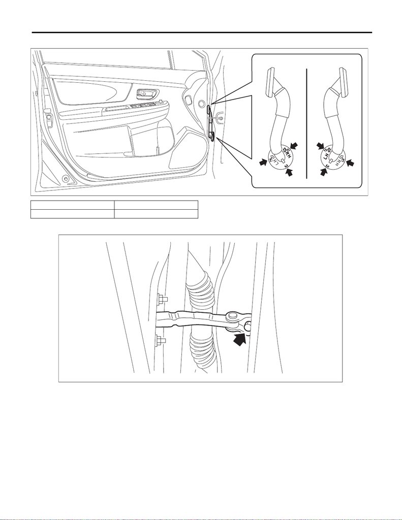

EB-27

Front Door

EXTERIOR BODY PANELS

(2) Push in the claws to remove the grommet, and pull out the door harness connector.

4) Remove the bolts on the vehicle side to disconnect the checker assembly - front door.

A Driver’s side

B Passenger’s side

EB-00753

AB

EB-01012

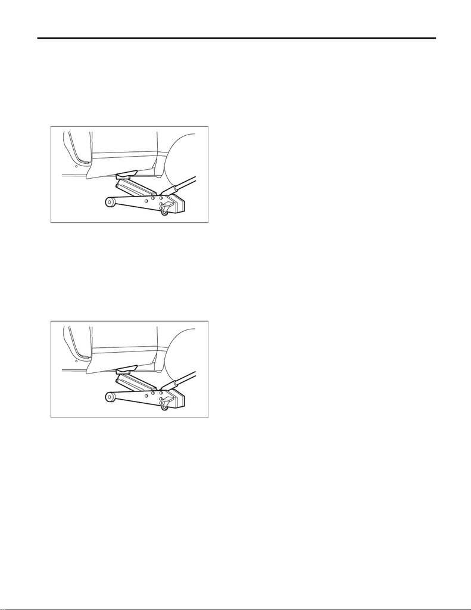

EB-28

Front Door

EXTERIOR BODY PANELS

5) Before removing the door hinge, make the following preparations.

CAUTION:

• The panel assembly - front door is heavy. When removing and installing it, always work in a team

of two or more persons.

• Do not excessively lift the panel assembly - front door with the floor jack. The door hinges may be

damaged.

(1) Put a wooden block on a floor jack and place the jack under the panel assembly - front door.

(2) Support the panel assembly - front door with the jack to protect it from damage.

6) Remove the bolts on the side of the panel assembly - front door of the upper hinge - front door or the lower

hinge - front door.

CAUTION:

Do not remove the upper hinge - front door and the lower hinge - front door at the same time.

7) Remove the hinge - front door from the vehicle.

B: INSTALLATION

1. FRONT DOOR PANEL

1) Put a wooden block and the like on a jack and place the panel assembly - front door on it.

2) Adjust the height by the jack, and temporarily install the panel assembly - front door to the upper hinge -

front door and the lower hinge - front door.

NOTE:

• When installing the panel assembly - front door, make sure that a uniform clearance is created around the

panel.

• Perform installation while paying attention to the assembly direction of the grommet.

3) Adjust the clearance around the panel assembly - front door. <Ref. to EB-30, ADJUSTMENT, Front

Door.>

4) Tighten the mounting bolts of the panel assembly - front door to the specified torque.

Tightening torque:

25 N·m (2.5 kgf-m, 18.4 ft-lb)

5) Tighten the bolts and nuts of the checker assembly - front door.

Tightening torque:

Refer to “COMPONENT” of “General Description”. <Ref. to EB-4, FRONT DOOR, COMPONENT,

General Description.>

EB-00013

EB-00013

[figure not shown]

EB-29

Front Door

EXTERIOR BODY PANELS

6) Connect door harness connector, and install the cover side sill - front. <Ref. to EI-84, INSTALLATION,

Lower Inner Trim.>

7) Install door internal parts in the reverse order of removal.

• Weather strip - front door

• Handle - door outer

Tightening torque:

7.5 N·m (0.8 kgf-m, 5.5 ft-lb)

• Latch & actuator ASSY - front

Tightening torque:

6.5 N·m (0.7 kgf-m, 4.8 ft-lb)

• Regulator & motor assembly - front for the front door

Tightening torque:

7.5 N·m (0.8 kgf-m, 5.5 ft-lb)

• Glass assembly - front door, and glass - front door partition

Tightening torque:

7.5 N·m (0.8 kgf-m, 5.5 ft-lb)

8) Install the airbag door sensor.

CAUTION:

Do not reuse the bolt and nut.

Always replace with the specified new bolts and nuts.

Tightening torque:

7.5 N·m (0.8 kgf-m, 5.5 ft-lb)

9) Install the cover B pillar - front door INN.

CAUTION:

Always replace with a new part, because engagement of the claw weakens.

10) Install the front door speaker assembly.

11) Install the outer mirror assembly.

Tightening torque:

7.5 N·m (0.8 kgf-m, 5.5 ft-lb)

12) Install the sealing cover. <Ref. to EB-32, INSTALLATION, Front Sealing Cover.>

13) Install the trim panel - front door. <Ref. to EI-58, INSTALLATION, Door Trim.>

14) Connect the battery ground terminal. <Ref. to NT-5, BATTERY, NOTE, Note.>

NOTE:

For models other than STI model, connect the ground terminal to battery sensor.

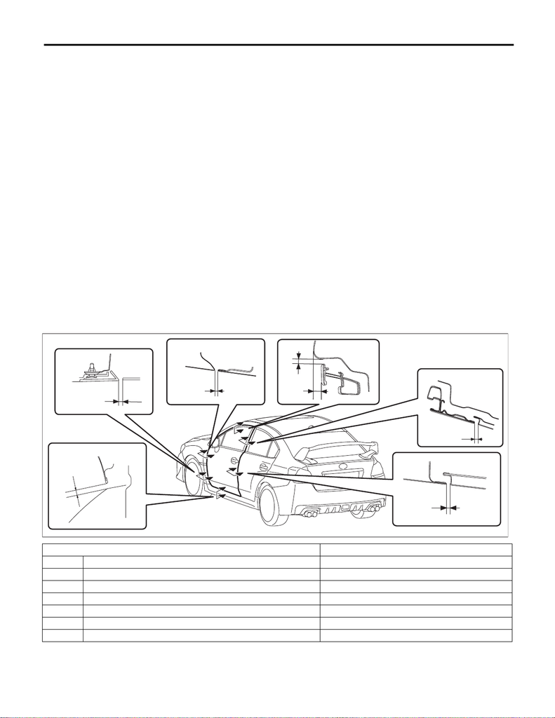

EB-30

Front Door

EXTERIOR BODY PANELS

2. FRONT DOOR HINGE

1) Apply grease to the sliding area of door hinges, and install the door hinge to vehicle.

Tightening torque:

30 N·m (3.1 kgf-m, 22.1 ft-lb)

2) Adjust the height by the jack, and temporarily install the panel assembly - front door to the upper hinge -

front door and the lower hinge - front door.

NOTE:

When installing the panel assembly - front door, make sure that a uniform clearance is created around the

panel.

3) Adjust the clearance around the panel assembly - front door. <Ref. to EB-30, ADJUSTMENT, Front

Door.>

4) Tighten the bolts of the panel assembly - front door to the specified torque.

Tightening torque:

25 N·m (2.5 kgf-m, 18.4 ft-lb)

5) Connect door harness connector, and install the cover side sill - front. <Ref. to EI-84, INSTALLATION,

Lower Inner Trim.>

6) Tighten the bolts on the vehicle side of the checker assembly - front door.

Tightening torque:

Refer to “COMPONENT” of “General Description”. <Ref. to EB-4, FRONT DOOR, COMPONENT,

General Description.>

C: ADJUSTMENT

Adjust the clearance around the panel assembly - front door as follows.

Part Standard

A Fender COMPL - front to Panel assembly - front door 4.5±1.0 mm (0.18±0.04 in)

B Panel assembly - front door to Garnish assembly - fender 4.5±1.0 mm (0.18±0.04 in)

C Panel assembly - front door to Spoiler assembly - side 6.0+1.5, –1.0 mm (0.24+0.06, –0.04 in)

D Panel - side outer to Front door sash 5.1+1.5, –1.0 mm (0.20+0.06, –0.04 in)

E Surface level gap between Panel - side outer to Front door sash 7±1.5 mm (0.28±0.06 in)

F Front door sash to Rear door sash 5.5+1.5, –1.0 mm (0.22+0.06, –0.04 in)

G Panel assembly - front door to Panel assembly - rear door 4.5±1.0 mm (0.18±0.04 in)

EB-00969

G

A

F

C

D

E

B

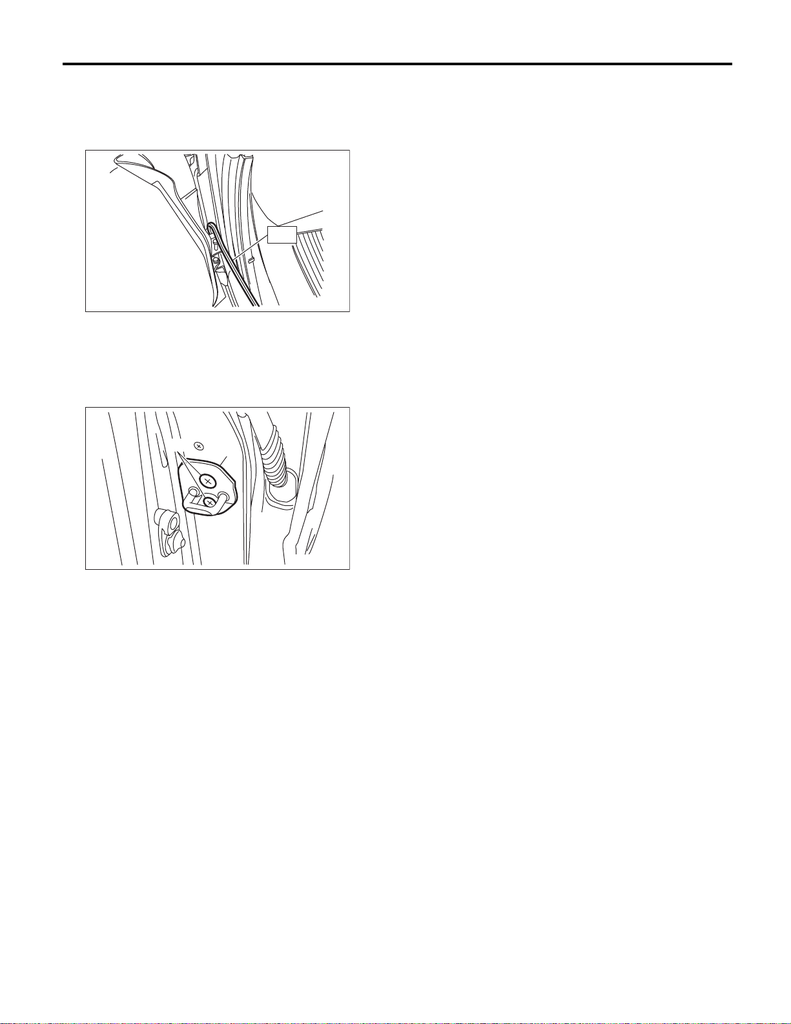

EB-31

Front Door

EXTERIOR BODY PANELS

1) Adjust the vertical and horizontal positions of the panel assembly - front door.

(1) Using ST, loosen the bolts on vehicle side of the upper hinge - front door.

Preparation tool:

ST: WRENCH (925610000)

(2) Turn over the mud guard, and loosen the bolts on vehicle side of the lower hinge - front door.

(3) Adjust the vertical and horizontal clearance of the panel assembly - front door.

2) Adjust the surface level gap between the panel assembly - front door and the panel assembly - rear door.

CAUTION:

Do not use an impact wrench. Welding area on the striker nut plate is easily broken.

(1) Loosen the screws (A).

(2) Tap the striker - front door (B) using a plastic hammer to adjust the surface level gap between the rear

end of the panel assembly - front door and the front end of the panel assembly - rear door.

EB-00016

ST

EB-00017

(B)

(A)